# Free Fares, Fuller Buses

Ridership, service and riders on Boston’s fare-free bus routes (23, 28 and 29)

Authors

Esha Gupta

Sahil Mittal

Published

October 2026

Abstract

In 2021–2022 the City of Boston made MBTA bus Routes 23, 28 and 29 fare-free. Using MBTA ridership, service and passenger-survey data together with U.S. Census data, we compare these routes with Route 22, which serves the same neighbourhoods but kept its fare. From 2019 to 2025 the fare-free routes lost far fewer riders than comparable routes, even though they lost service while Route 22 gained it. After adjusting for service, all three fare-free routes outperformed Route 22, and the advantage of 15–17 percentage points holds against the wider bus network. Route 29, whose service was cut by more than a third, shows the limit of the policy: free fares cannot make up for fewer buses.

[figure not shown]

# 1 Introduction

## 1.1 Research question

> **Who rides Boston’s fare-free bus routes, and how did ridership and service on these routes change over the years, compared with similar routes that kept regular fares?**

## 1.2 Why this question?

For many city residents, public transit is the main way to reach jobs, school and health care, yet less than half the world’s urban population has convenient access to it (United Nations 2020). People without good transit face longer and less safe commutes (World Bank, n.d.), higher costs, and exclusion from economic and social opportunities (London School of Economics and Political Science, n.d.). Service that is frequent and reliable is what lets people depend on transit for daily needs (Institute for Transportation and Development Policy 2024).

## 1.3 Why Boston?

Boston’s rapid transit lines largely bypass Roxbury, Dorchester and Mattapan, which are lower-income neighbourhoods with mostly residents of colour, leaving them dependent on buses (Cook 2024). Boston’s fare-free bus program was designed to address this gap. Using federal pandemic relief funds, the City made Route 28 free as a pilot in **August 2021**, reimbursing the MBTA for each ride. After early results showed ridership gains and high rider satisfaction, the program expanded to Routes 23 and 29 in **March 2022** (City of Boston 2026a). It has since been extended through **December 31, 2026**, with no decision yet on what comes next (City of Boston 2026b).

We compare the fare-free routes (**23, 28, 29**) with **Route 22**, which runs through the same neighbourhoods but still charges a fare.

# 2 Data

We combine seven public datasets (Table 1). Routes link across datasets through their MBTA route IDs, and neighbourhoods through census tract IDs.

Table 1: Data sources

| Dataset | Source | Years | Used for |
| --- | --- | --- | --- |
| Bus ridership by trip, season, route and stop | MassDOT (Massachusetts Department of Transportation 2025b) | Fall 2016–2025 | Weekday riders on each route |
| Bus arrival and departure times | MBTA (Massachusetts Bay Transportation Authority 2025) | 2020–2025 | Service (trips run) |
| Systemwide Passenger Survey | CTPS (Central Transportation Planning Staff 2018) | 2015–2017 | Riders before the program |
| System-Wide Passenger Survey | MassDOT (Massachusetts Department of Transportation 2025a) | 2022–2025 | Riders during the program |
| American Community Survey, 5-year | U.S. Census Bureau (U.S. Census Bureau 2025) | 2015–19, 2020–24 | Who lives along each route |
| TIGER/Line census tracts | U.S. Census Bureau (U.S. Census Bureau 2024) | 2019, 2024 | Neighbourhood maps |
| GTFS schedule data | MBTA (Massachusetts Bay Transportation Authority 2026) | 2026 | Stop locations and route paths |

Ridership comes from **automatic passenger counters** rather than fare data: riders on the fare-free routes do not tap a fare card, so fare data cannot count them, while passenger counters measure everyone who boards in the same way before and after the program.

# 3 Methods

## 3.1 Comparison design

We use a **difference-in-differences** comparison (Angrist and Pischke 2009): the change on the fare-free routes minus the change on a comparison route over the same period. This removes changes that affected every route, such as COVID and remote work, leaving the difference linked to free fares. The main comparison is **Route 22**; we check the result against the **8 busiest other routes** (1, 66, 39, 57, 111, 32, 22 and 9) and **all other routes**. Silver Line routes are excluded because they are bus rapid transit with different ridership drivers.

## 3.2 Adjusting for service

A route that loses buses loses riders, regardless of the fare. Therefore, we also measure ridership **relative to service**, the change in riders per trip run:

$$\text{Adjusted change} = \left(\frac{1 + \text{riders change}/100}{1 + \text{service change}/100} - 1\right) \times 100$$

For example, Route 23’s riders rose 1.0% while its service fell 7.2%: 1.010 ÷ 0.928 = 1.088, so riders per trip rose 8.8%.

**Periods:** riders are compared from Fall 2019 to Fall 2025. Service data begins in 2020, so service is compared from January–February 2020 (before COVID and the program) to January–February 2025.

# 4 Findings

## 4.1 Who lives along the routes and who rides them

The three fare-free routes and Route 22 serve similar neighbourhoods. Figure Figure 1 locates the four routes and shows the tract-level income pattern across the two ACS periods. The same route geometry is used on both panels, so the map compares ACS geography and income rather than historical route changes.

[figure not shown]

Figure 1: Median household income by census tract along Routes 22, 23, 28, and 29, shown for two ACS periods.

Figure Figure 2 compares residents, median income, poverty, vehicle access, minority share, and rent burden in each route area across the two ACS periods. Route areas can overlap, so resident counts are not unique populations.

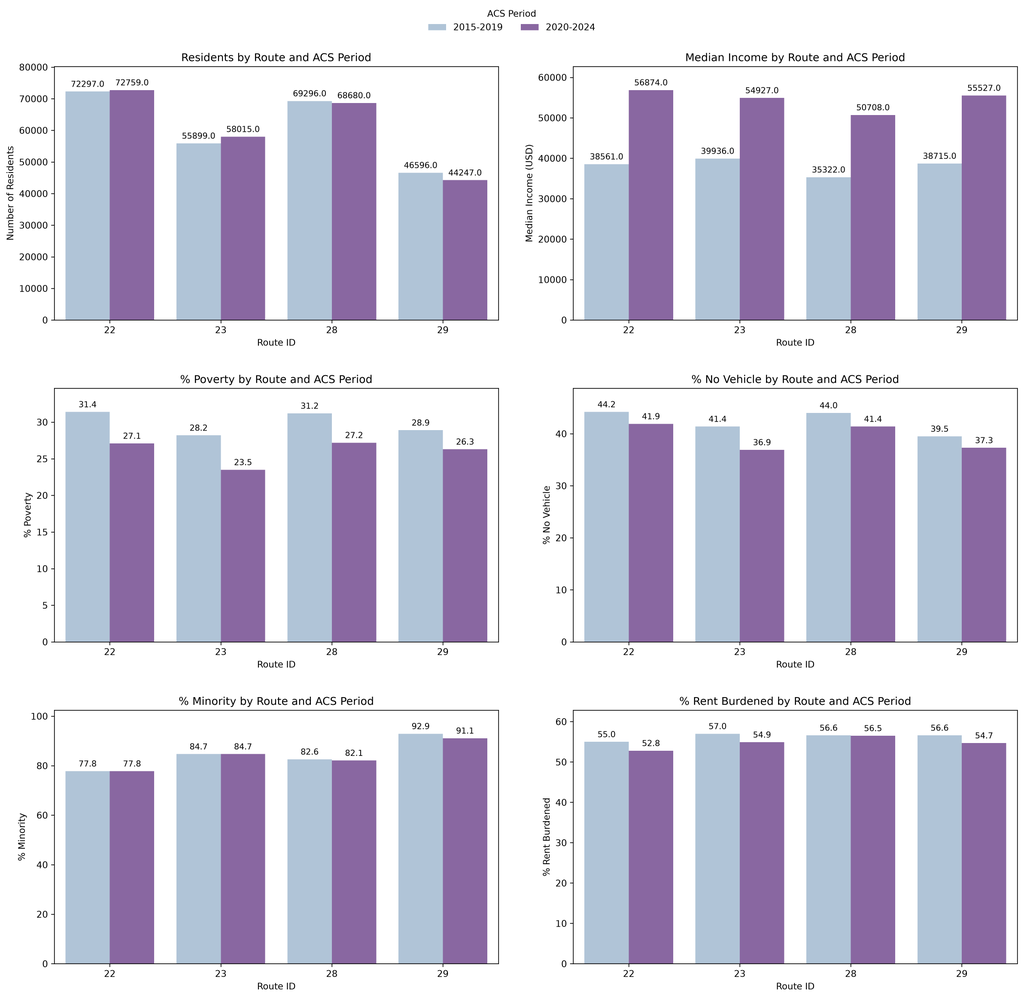

Figure 2: Route-area characteristics for Routes 22, 23, 28, and 29 across the 2015–2019 and 2020–2024 ACS periods.

The riders on these routes also share similar characteristics (Figure 3). Riders on all four routes are more likely to be people of colour and to live without a car than the average MBTA bus rider. They are also slightly less likely to be commuting to work. Routes 28 and 29 are reported together in the survey.

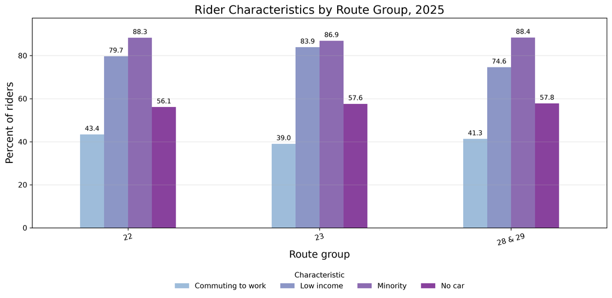

**Did free fares change who rides?** Route 23 is the only fare-free route reported separately in both surveys. Compared with all bus riders in the same year (Table 2), Route 23’s riders remain more car-free and less likely to commute to work, and they remain more likely to be low-income and people of colour. The program kept serving the same kind of riders rather than attracting a different, better-off group.

Table 2: Route 23 riders compared with all bus riders, before and during the program

|  | Route 23, 2015–17 | All buses, 2015–17 | Route 23, 2025 | All buses, 2025 |
| --- | --- | --- | --- | --- |
| Low-income | 59.0% | 41.4% | 83.9% | 77.6% |
| Minority | 84.9% | 48.1% | 86.9% | 69.4% |
| No car in household | 47.1% | 39.0% | 57.6% | 48.6% |
| Commuting to work | 59.5% | 69.8% | 39.0% | 47.3% |

Two cautions apply to Table 2. The MBTA’s definition of “low-income” changed between the surveys, so low-income shares should be compared within a year, not across years. And the fall in work trips happened on every route, reflecting the rise of remote work rather than the fare change.

## 4.2 Ridership on the fare-free routes

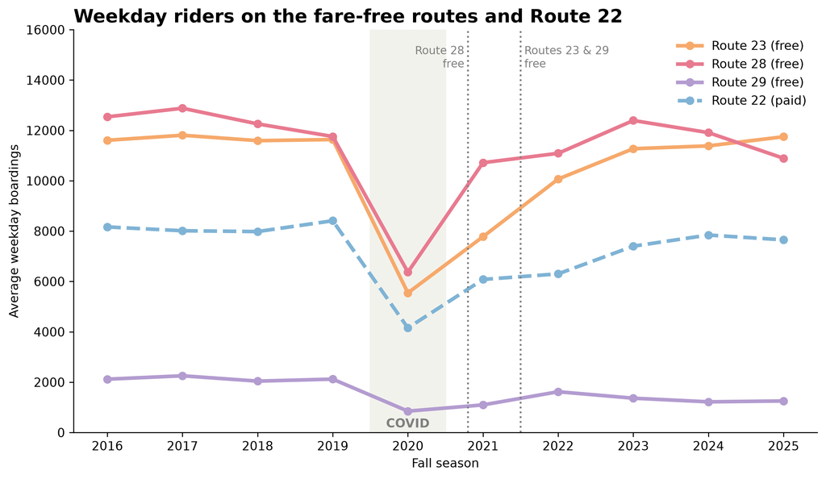

Figure 4: Weekday riders on the fare-free routes and Route 22, Fall 2016–2025

All four routes collapsed in 2020 (Figure 4). Route 28 rebounded sharply in its first fare-free fall (2021), and Route 23 climbed back to its pre-COVID level after becoming free in 2022. Route 22, which kept its fare, is still below its 2019 ridership. Route 29 stayed low, reflecting the service cuts described below.

Boardings per 100 residents provide another way to compare route activity with the size of nearby populations (Figure 5). These are boardings, not counts of unique residents who ride; route areas can overlap and riders may live outside them.

[figure not shown]

Figure 5: Weekday boardings per 100 residents and percentage change in residents and riders on Routes 22, 23, 28, and 29.

### 4.2.1 Did neighbourhood conditions change with ridership?

The next figures compare route-area characteristics with the change in weekday riders from 2019 to 2025. They show associations across routes, not evidence that demographic changes caused ridership changes.

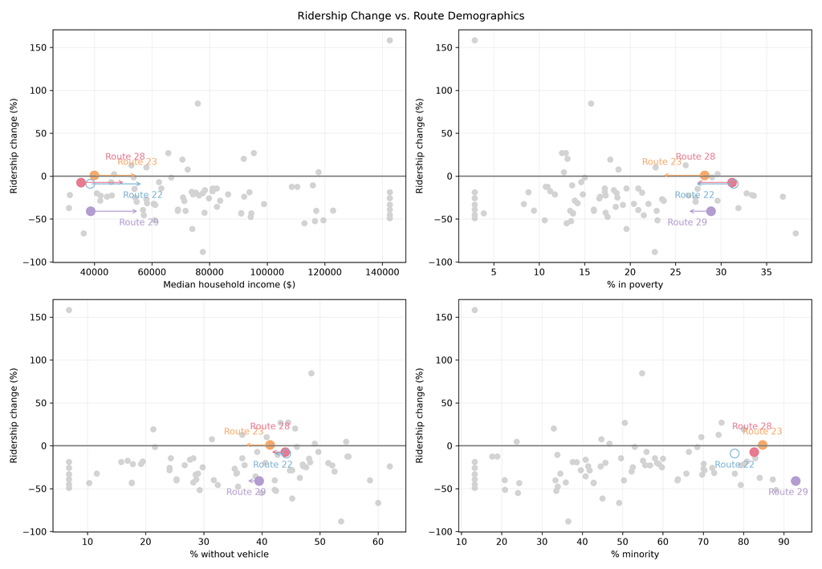

Figure 6: Ridership change against route-area income, poverty, vehicle access, and minority share. Arrows show the change between ACS periods.

The income-focused views show the relationship both with the later-period income level (Figure 7) and with the percentage change in income (Figure 8). The income-change measure is nominal and is not adjusted for inflation.

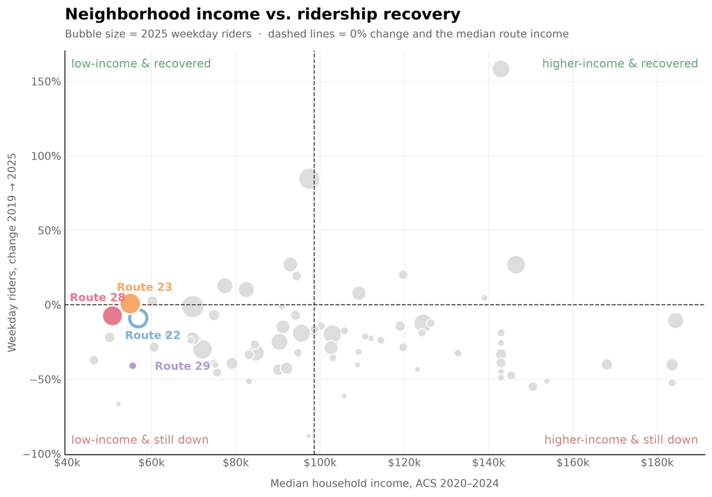

Figure 7: Later-period route-area median income compared with weekday ridership change from 2019 to 2025.

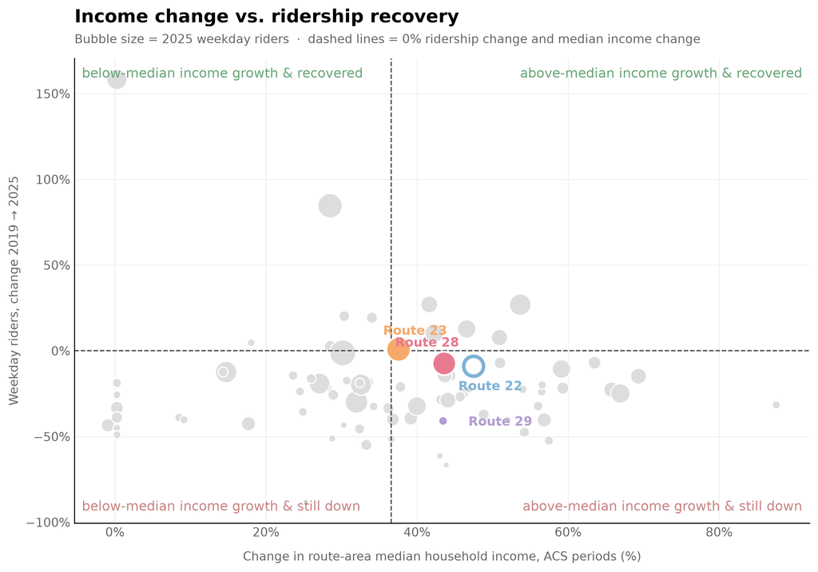

Figure 8: Percentage change in route-area median income compared with weekday ridership change.

## 4.3 Did ridership simply follow service?

If the fare-free routes had simply been given more buses, more riders would be expected regardless of the fare. Figure 9 shows the opposite.

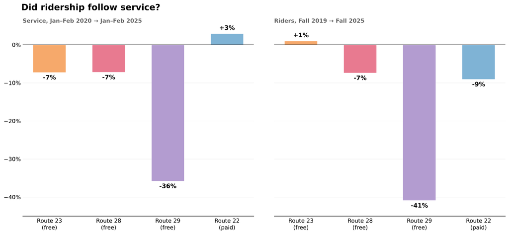

Figure 9: Change in service (weekday trips) and in riders (weekday boardings), before COVID to 2025

Table 3: Riders and service on the four routes. Riders: Fall 2019 → Fall 2025; service: January–February 2020 → January–February 2025.

| Route | Riders change | Service change | vs. Route 22, raw | vs. Route 22, adjusted for service |
| --- | --- | --- | --- | --- |
| 23 (free) | +1.0% | −7.2% | +10.0 pts | **+20.4 pts** |
| 28 (free) | −7.4% | −7.2% | +1.7 pts | **+11.4 pts** |
| 29 (free) | −40.9% | −35.8% | −31.9 pts | **+3.6 pts** |
| 22 (paid) | −9.0% | +2.9% | — | — |

Route 22 gained 2.9% more service but still lost 9.0% of its riders (Table 3). Route 23 lost 7.2% of its service yet gained riders, and Route 28 lost riders only in line with its service cut. Route 29’s ridership fell almost as far as its service: free fares could not offset deep service cuts.

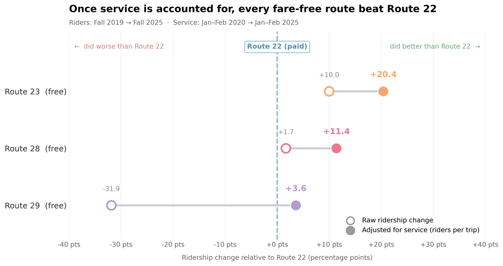

Figure 10: Fare-free routes compared with Route 22, before and after adjusting for service

Because Route 22 gained service while the fare-free routes lost it, the raw comparison understates the fare-free routes’ advantage. Once ridership is measured relative to service (Figure 10), **all three fare-free routes outperformed Route 22**: Route 23 by 20.4 percentage points, Route 28 by 11.4 and Route 29 by 3.6. Ridership usually falls less than one-for-one with service, so these adjusted gaps are an upper estimate; the true effect lies between the raw and adjusted values.

## 4.4 The fare-free routes in the wider network

Across the network, the fare-free routes recovered far more of their pre-COVID riders than other routes (Table 4).

Table 4: Change in total weekday riders by group (Silver Line excluded)

| Group | Change in weekday riders, Fall 2019 → Fall 2025 |
| --- | --- |
| Fare-free routes (23, 28, 29) | −6.3% |
| 8 busiest other routes | −18.7% |
| All other routes | −22.8% |

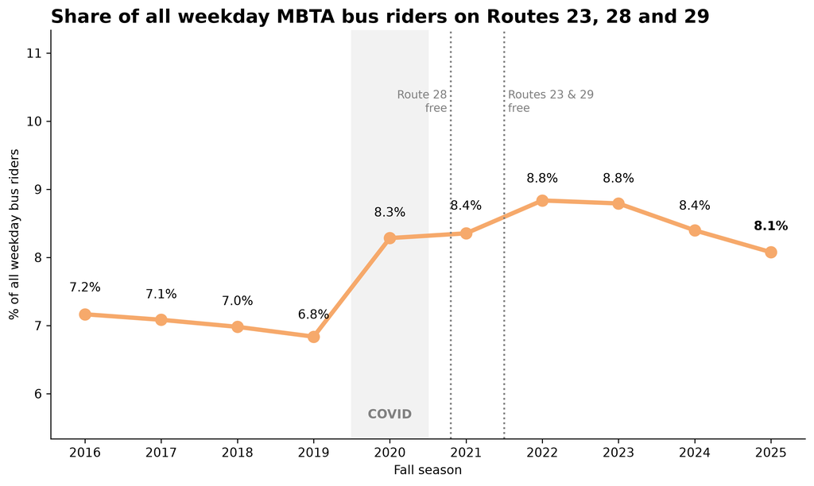

Figure 11: Fare-free routes’ share of all weekday MBTA bus riders

The fare-free routes’ share of all weekday bus riders rose from 6.8% in 2019 to 8.8% in 2022–2023, before easing to 8.1% in 2025 (Figure 11). Much of the jump happened in 2020, before fares were removed, as riders on these routes kept riding through COVID more than riders elsewhere; the rise after 2021 (8.4% to 8.8%) is the part more plausibly linked to free fares.

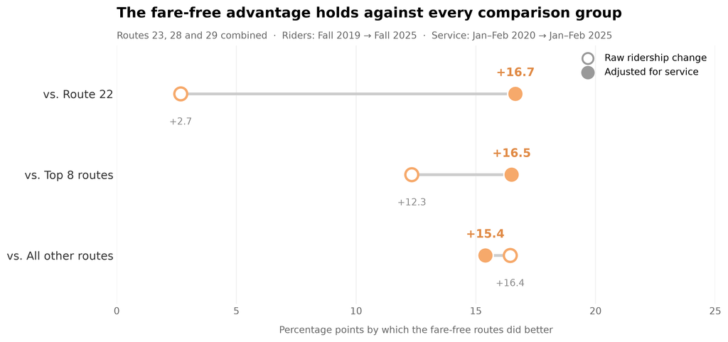

Figure 12: The fare-free advantage against each comparison group

The result does not depend on choosing Route 22 (Figure 12, Table 5). After adjusting for service, the fare-free routes did 15.4 to 16.7 points better than every comparison group, a remarkably consistent result.

Table 5: Fare-free routes (combined) compared with each group, Fall 2019 → Fall 2025

| Fare-free routes compared with | Raw gap | Gap adjusted for service |
| --- | --- | --- |
| Route 22 | +2.7 pts | +16.7 pts |
| 8 busiest other routes | +12.3 pts | +16.5 pts |
| All other routes | +16.4 pts | +15.4 pts |

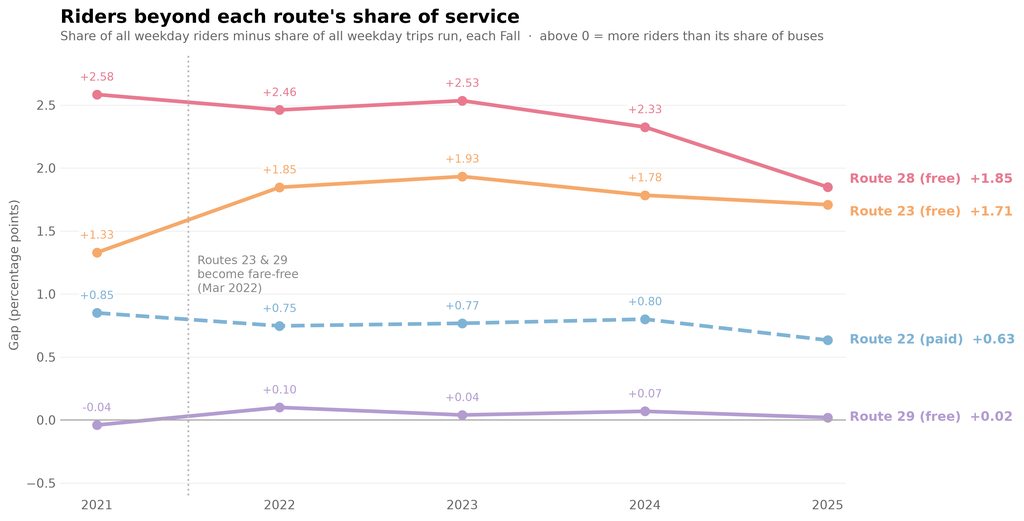

Figure 13: Each route’s share of riders minus its share of trips run

Finally, Figure 13 shows how many more riders each route carries than its share of service would suggest. Route 23’s gap rose when it became fare-free (from +1.33 percentage points in 2021 to +1.85 in 2022) and stayed above its pre-program level, while Route 22’s gap stayed flat at about +0.6 to +0.85. Route 28, already fare-free in 2021, carries the most riders relative to its service of the four routes. Route 29 carries roughly its share of riders for its share of buses.

# 5 Limitations

## 5.1 Study Design

- **Few treated routes.** Only three routes are fare-free (23, 28, 29), so results show patterns rather than proof, and formal statistical tests have limited power.
- **Other changes overlapped with the program.** COVID recovery, new bus lanes and the Bus Network Redesign happened in the same years. Comparison routes help separate these from the fare-free effect but cannot remove them entirely.
- **Route 29 is much smaller** (about 2,100 weekday boardings in 2016 vs. about 12,000 on Routes 23 and 28). Combined totals mostly reflect Routes 23 and 28, and Route 29’s percentage changes can look large from small absolute changes.
- **No individual-level data.** Rider and resident comparisons use aggregated survey and census figures, not the same people.
- **Bus Size** The route 29 bus size is much smaller than buses on the other routes which makes the number of riders per trip lesser in route 29. Since we do not have bus frequency data, the ridership on route 29 automatically becomes smaller.

## 5.2 Bus Ridership

- **Fall only.** Ridership data covers one season (Fall) per year, so it shows year-to-year trends but not month-to-month changes.
- **Passenger counter averages.** Values are averages from automatic passenger counters across sampled trips, not complete counts.
- **2020 is a COVID year.** Fall 2020 ridership was far below normal and is excluded from before/after comparisons.

## 5.4 Passenger Surveys

- **Route grouping differs between surveys.** 2015–17 reports Routes 22 and 29 together (“22 and 29”); 2025 reports Routes 28 and 29 together (“28 & 29”). Route 23 is the only fare-free route reported separately in both.
- **2025 release pools 2022–2025 responses**, so it describes riders across the program period rather than a single year.
- **Income measured differently.** 2015–17 uses dollar brackets; 2025 uses shares of Area Median Income. Low-income and minority classifications are the most comparable measures.
- **Sampling error.** Both surveys are weighted samples; 2015–17 reports response counts but no margins of error.

# 6 Conclusion

Free fares did not reverse the post-pandemic fall in bus ridership in Boston, but they made a clear difference to how much of it the fare-free routes recovered. From 2019 to 2025, Routes 23, 28 and 29 together lost 6.3% of their weekday riders, against 18.7% on the busiest other routes and 22.8% across the rest of the network. This was not because they received more buses: Route 22, which kept its fare, gained service but lost riders, while the fare-free routes lost service and still held on to theirs. Once service changes are taken into account, all three fare-free routes outperformed Route 22, and the advantage of roughly 15–17 percentage points is consistent across every comparison group.

The program also kept serving the riders it was designed for: people in lower-income, transit-dependent neighbourhoods, most of them people of colour and many without a car. Route 29 shows the limit of the policy. Its service was cut by more than a third and its ridership fell almost as much, so free fares cannot substitute for frequent, reliable service. As the City decides what happens after December 2026, the evidence suggests that removing fares helps routes hold on to riders, but only alongside maintaining the service those riders depend on.

Future research could examine whether these ridership trends continue beyond 2026, particularly if the fare-free program is extended or discontinued. More detailed data on service frequency, reliability and passenger travel patterns would help separate the effects of free fares from changes in bus service and post-pandemic travel behaviour. Comparing Boston’s experience with other cities that have introduced fare-free transit could also help establish whether the results hold beyond these three routes.

# 7 Supplementary Demographic Charts

These figures provide additional views of the route-area and rider characteristics discussed above.

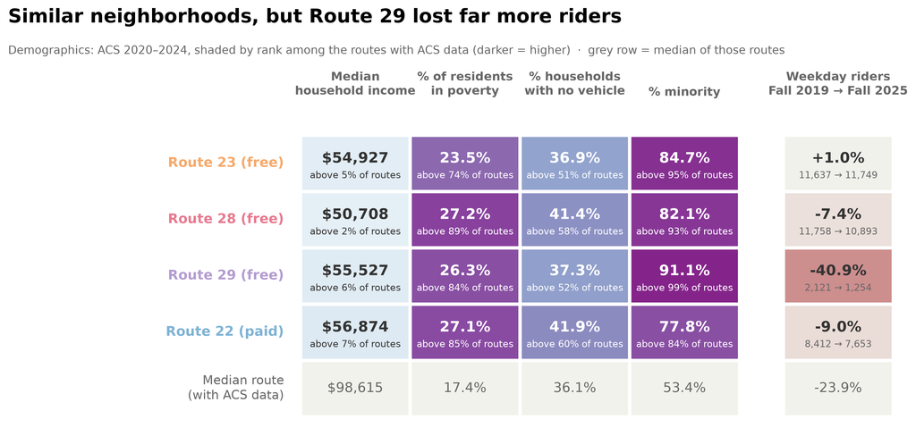

Figure 14: Summary table of demographic characteristics by route area.

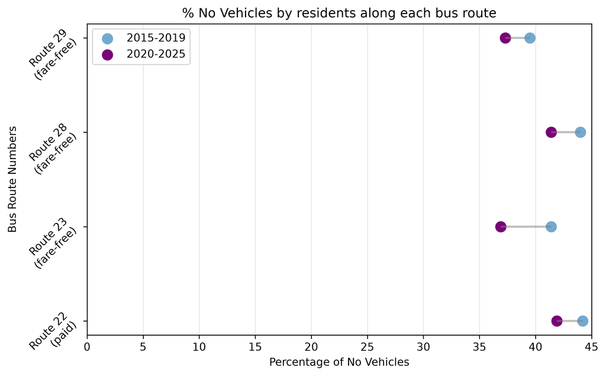

Figure 15: Share of households without a vehicle along each route in the two ACS periods.

# Use of AI tools

We used Claude, an AI assistant developed by Anthropic (Anthropic 2026), for support with Python code debugging, chart design and editing text. All analysis decisions, interpretation and final writing are our own, and every result was checked against the data.

# References

Angrist, Joshua D., and Jörn-Steffen Pischke. 2009. *Mostly Harmless Econometrics: An Empiricist’s Companion*. Princeton University Press.

Anthropic. 2026. *Claude (Opus 5.5)*. Large language model. https://claude.ai.

Central Transportation Planning Staff. 2018. *2015–2017 MBTA Systemwide Passenger Survey*. Boston Region Metropolitan Planning Organization. https://www.ctps.org/dv/mbtasurvey2018/index.html.

City of Boston. 2026a. *Free Route 23, 28, and 29 Bus Program*. https://www.boston.gov/departments/transportation/free-route-23-28-and-29-bus-program.

City of Boston. 2026b. *Mayor Michelle Wu, Secretary Phil Eng Announce Extension of Fare-Free Transit Program*. https://www.boston.gov/news/mayor-michelle-wu-secretary-phil-eng-announce-extension-fare-free-transit-program.

Institute for Transportation and Development Policy. 2024. *Our Cities Need More People Near Frequent and Rapid Public Transport*. https://itdp.org/2024/07/24/our-cities-need-more-people-near-frequent-and-rapid-public-transport/.

London School of Economics and Political Science. n.d. *Urban Transport and Low Traffic Neighbourhood Policy*. LSE Research for the World. https://www.lse.ac.uk/research/research-for-the-world/politics/urban-transport-ltn-policy.

Massachusetts Bay Transportation Authority. 2025. *MBTA Bus Arrival Departure Times, 2020–2025*. MBTA Blue Book Open Data Portal. https://mbta-massdot.opendata.arcgis.com/.

Massachusetts Bay Transportation Authority. 2026. *MBTA GTFS Static Feed*. https://www.mbta.com/developers/gtfs.

Massachusetts Department of Transportation. 2025a. *MBTA 2025 System-Wide Passenger Survey*. MassGIS Data Hub. https://gis.data.mass.gov/datasets/MassDOT::mbta-2025-system-wide-passenger-survey.

Massachusetts Department of Transportation. 2025b. *MBTA Bus Ridership by Trip, Season, Route/Line, and Stop*. MassGIS Data Hub. https://gis.data.mass.gov/datasets/8daf4a33925a4df59183f860826d29ee.

United Nations. 2020. *The Sustainable Development Goals Report 2020: Goal 11*. https://unstats.un.org/sdgs/report/2020/goal-11/.

U.S. Census Bureau. 2024. *TIGER/Line Shapefiles: Census Tracts, Massachusetts (2019 and 2024)*. https://www.census.gov/geographies/mapping-files/time-series/geo/tiger-line-file.html.

U.S. Census Bureau. 2025. *American Community Survey 5-Year Estimates, 2015–2019 and 2020–2024*. https://www.census.gov/data/developers/data-sets/acs-5year.html.

World Bank. n.d. *Road Safety Is an Issue of Equity for the Poor*. Voices blog. https://blogs.worldbank.org/en/voices/road-safety-is-an-issue-of-equity-for-the-poor.